# Gastos no cartão corporativo presidencial entre 2003 e 2022

# 1. Contexto

No dia 12 de janeiro de 2023 foram divulgados os dados dos gastos do CPGF (Cartão de Pagamento do Governo Federal) [^1]. Por curiosidade resolvi analisar a planilha, a intenção inicial era fazer um comparativo entre os gastos do diversos governos com dados corrigidos pela inflação.

Para tal, utilizo o pacote do R `deflateBR` [^2], que extrai dados dos principais índices de preços da API do IPEA, compatibiliza as datas mensais desses índices com as datas dos valores nominais da série e, por fim, deflaciona e retorna os valores corrigidos. O índice escolhido foi o IPCA (Índice Nacional de Preços ao Consumidor Amplo), por ser o principal índice brasileiro de inflação.

- Os maiores gastos foram feitos durante o governo Lula e há considerável diminuição das compras a partir do governo Dilma/Temer.
- A grande maioria das despesas é feita em hospedagem ou alimentação.
- Hospedagem é a categoria com mais gastos, com o valor acumulado de R$ 99.546.417 (valores corrigidos pelo IPCA dez-2022) ao longo dos últimos 20 anos.
- Desde o início da série foram gastos R$ 210.556.492 no CPGF.
- Há de se destacar as despesas no Mercadinho La Palma LTDA ao longo dos anos: foram 6.351.730 reais gastos no estabelecimento, o local com maior soma de gastos durante a série.

Entretanto, desde o começo da análise até a presente data, muitas dúvidas surgiram sobre a qualidade dos dados divulgados, o que põe em cheque qualquer tipo de comparação entre os governos. Segundo reportagem do UOL [^3], não se sabe se os gastos do presidente são referentes a apenas gastos individuais ou se englobam outras secretarias. Além disso, há inconsistências entre os dados apresentados na planilha e os divulgados no portal da transparência [^4].

Ainda assim, continuei a análise por curiosidade. Entretanto, é interessante ter uma boa dose de ceticismo ao fazer comparações.

# 2. Pré-processamento dos dados

## Carregando os pacotes

```r
#carregando as bibliotecas
library(tidyverse)
library(ggplot2)
library(deflateBR)
library(stringr)
library("skimr")
library("scales")
library(patchwork)
library(knitr)
library(kableExtra)
library(htmltools)
```

```r
#retirando a notação cientifica
options(scipen=999)
```

```r
#mudando o diretório
setwd('C:/Users/SAMSUNG/OneDrive/Documentos/GitHub/cartao_corporativo')
```

Os dados utilizados nessa análise podem ser encontrados aqui.

## Loading da base

```r
corporativo <- read.csv2('corporativo.csv', encoding='LATIN1')
```

```r
corporativo %>%
  head(10) %>%
  kbl() %>%
  kable_styling(bootstrap_options = c("striped", "condensed", "responsive", "hover"), full_width = FALSE)
```

| DATA.PGTO | CPF.SERVIDOR | CPF.CNPJ.FORNECEDOR | NOME.FORNECEDOR | VALOR | TIPO | SUBELEMENTO.DE.DESPESA | CDIC |
| --- | --- | --- | --- | --- | --- | --- | --- |
| 02/01/2003 | ***.010.008-** | 31349202000177 | JW TRANSPORTADORA TUR?TICA | R$ 1.696,90 | D | LOCACAO DE MEIOS DE TRANSPORTE | 00200.220539/2003-63.R.08.18/12/2002.31/12/2014.N |
| 02/01/2003 | ***.010.008-** | 31349202000177 | JW TRANSPORTADORA TUR?TICA | R$ 1.336,60 | D | LOCACAO DE MEIOS DE TRANSPORTE | 00200.220539/2003-63.R.08.18/12/2002.31/12/2014.N |
| 02/01/2003 | ***.868.251-** | 31349202000177 | JW TRANSPORTADORA TUR?TICA | R$ 1.396,43 | D | LOCACAO DE MEIOS DE TRANSPORTE | 00200.600539/2003-63.R.08.18/12/2002.31/12/2014.N |
| 03/01/2003 | ***.004.131-** | 592717000170 | FLORES ALVORADA | R$ 8.585,00 | C | OUTROS SERVI?OS DE TERCEIROS-PESSOA JUR?ICA | 00200.800212/2003-91.R.08.07/12/2002.31/12/2014.N |
| 03/01/2003 | ***.004.131-** | 839308000125 | CRISTAL LIMPEZA - COM?RCIO DE MATERIAIS PARA LIMPE | R$ 251,50 | C | MATERIAL DE LIMPEZA E PROD. DE HIGIENIZA?? | 00200.800212/2003-91.R.08.07/12/2002.31/12/2014.N |
| 03/01/2003 | ***.262.328-** | 2014093000139 | SEBASTI? ALVES DE SOUSA - ME | R$ 105,00 | D | MATERIAL P/MANUTEN?? DE BENS M?EIS | 00200.150539/2003-63.R.08.16/12/2002.31/12/2014.N |
| 03/01/2003 | ***.262.328-** | 2363792000194 | JO? LEITE NETO - ME - JLN ELETRONICOS | R$ 200,00 | D | MATERIAL P/MANUTEN?? DE BENS M?EIS | 00200.150539/2003-63.R.08.16/12/2002.31/12/2014.N |
| 03/01/2003 | ***.010.008-** | 96475389000109 | CONDOMINIO EDIFICIO THE PARK HALL | R$ 2.590,00 | D | HOSPEDAGENS | 00200.220539/2003-63.R.08.18/12/2002.31/12/2014.N |
| 03/01/2003 | ***.010.008-** | 1720459000122 | FULL TIME LOCA?? E SERVI?OS S/C LTDA | R$ 3.618,70 | D | LOCACAO DE MEIOS DE TRANSPORTE | 00200.220539/2003-63.R.08.18/12/2002.31/12/2014.N |
| 03/01/2003 | ***.262.471-** | 47508411013134 | COMPANHIA BRASILEIRA DE DISTRIBUI?? | R$ 716,40 | C | GENEROS DE ALIMENTA?? | 00200.900212/2003-91.R.08.18/12/2002.31/12/2014.N |

## Procurando por duplicatas

```r
sum(duplicated(corporativo)) %>%
  kbl() %>%
  kable_styling(bootstrap_options = c("striped", "condensed", "responsive", "hover"), full_width = TRUE)
```

| x |
| --- |
| 34578 |

Há 34578 linhas iguais no dataset. Por enquanto vamos deixá-las.

## Dropando colunas e linhas

```r
corporativo %>%
  tail(10) %>%
  kbl() %>%
  kable_styling(bootstrap_options = c("striped", "condensed", "responsive", "hover"), full_width = FALSE)
```

|  | DATA.PGTO | CPF.SERVIDOR | CPF.CNPJ.FORNECEDOR | NOME.FORNECEDOR | VALOR | TIPO | SUBELEMENTO.DE.DESPESA | CDIC |
| --- | --- | --- | --- | --- | --- | --- | --- | --- |
| 113333 | 03/12/2022 | ***.136.591-** | 3696869000100 | BIG TRANS COMERCIAL DE ALIMENTOS LTDA | 363,68 | C | GENEROS DE ALIMENTA?? | 00264.000642/2022-21.R.08.25/11/2022.31/12/2022.N |
| 113334 | 03/12/2022 | ***.136.591-** | 47508411094975 | COMPANHIA BRASILEIRA DE DISTRIBUI?? | 39,95 | C | GENEROS DE ALIMENTA?? | 00264.000642/2022-21.R.08.25/11/2022.31/12/2022.N |
| 113335 | 03/12/2022 | ***.136.591-** | 3696869000100 | BIG TRANS COMERCIAL DE ALIMENTOS LTDA | 58,03 | C | GENEROS DE ALIMENTA?? | 00264.000642/2022-21.R.08.25/11/2022.31/12/2022.N |
| 113336 | 03/12/2022 | ***.136.591-** | 17261661005728 | OUTBACK STEAKHOUSE RESTAURANTES BRASIL S/A | 179,5 | C | FORNECIMENTO DE ALIMENTA?? | 00264.000642/2022-21.R.08.25/11/2022.31/12/2022.N |
| 113337 | 03/12/2022 | ***.136.591-** | 39879944000116 | BIOMUNDO 105 NORTE COMERCIO DE ALIMENTOS | 54,95 | C | GENEROS DE ALIMENTA?? | 00264.000642/2022-21.R.08.25/11/2022.31/12/2022.N |
| 113338 | 04/12/2022 | ***.136.591-** | 47508411094975 | COMPANHIA BRASILEIRA DE DISTRIBUI?? | 518,07 | C | GENEROS DE ALIMENTA?? | 00264.000642/2022-21.R.08.25/11/2022.31/12/2022.N |
| 113339 | 04/12/2022 | ***.136.591-** | 12550441000146 | RESTAURANTE SOHO | 330,52 | C | FORNECIMENTO DE ALIMENTA?? | 00264.000642/2022-21.R.08.25/11/2022.31/12/2022.N |
| 113340 | 04/12/2022 | ***.136.591-** | 3696869000100 | BIG TRANS COMERCIAL DE ALIMENTOS LTDA | 54,66 | C | GENEROS DE ALIMENTA?? | 00264.000642/2022-21.R.08.25/11/2022.31/12/2022.N |
| 113341 | Fonte: SUPRIM |  | NA |  |  |  |  |  |
| 113342 | At? 19/12/2022 |  | NA |  |  |  |  |  |

- removendo as duas ultimas linhas da nota de rodapé

```r
corporativo <- corporativo[-c(113341,113342 ), ]
```

- removendo as colunas `CPF.SERVIDOR`, `CPF.CNPJ.FORNECEDOR`, `TIPO` e `CDIC`

```r
corporativo = subset(corporativo, select = -c(CPF.SERVIDOR, CPF.CNPJ.FORNECEDOR, TIPO,CDIC ))
```

## Passando `DATA.PGTO` para datetime

```r
corporativo$DATA.PGTO = as.Date(corporativo$DATA.PGTO, format = '%d/%m/%Y')
```

## Ajeitando a coluna `VALOR`

- Tirando o R$

```r
corporativo$VALOR <- str_extract(corporativo$VALOR, "(\\d.+)")
```

- Substituindo o . por , e a , por .

```r
corporativo$VALOR <- gsub("[.]", "", corporativo$VALOR)

corporativo$VALOR <- str_replace(corporativo$VALOR, "," , ".")
```

## Convertendo `VALOR` para número

```r
corporativo$VALOR <- as.numeric(corporativo$VALOR)
```

## Checando dados faltantes

```r
sum(is.na(corporativo)) %>%
  kbl() %>%
  kable_styling(bootstrap_options = c("striped", "condensed", "responsive", "hover"), full_width = TRUE)
```

| x |
| --- |
| 14 |

Há dados faltantes

```r
skim_without_charts(corporativo)
```

Data summary

| Name | corporativo |
| --- | --- |
| Number of rows | 113340 |
| Number of columns | 4 |
| _______________________ |  |
| Column type frequency: |  |
| character | 2 |
| Date | 1 |
| numeric | 1 |
| ________________________ |  |
| Group variables | None |

**Variable type: character**

| skim_variable | n_missing | complete_rate | min | max | empty | n_unique | whitespace |
| --- | --- | --- | --- | --- | --- | --- | --- |
| NOME.FORNECEDOR | 0 | 1 | 3 | 97 | 0 | 8607 | 0 |
| SUBELEMENTO.DE.DESPESA | 0 | 1 | 4 | 50 | 0 | 112 | 0 |

**Variable type: Date**

| skim_variable | n_missing | complete_rate | min | max | median | n_unique |
| --- | --- | --- | --- | --- | --- | --- |
| DATA.PGTO | 0 | 1 | 2003-01-02 | 2022-12-19 | 2010-02-19 | 6670 |

**Variable type: numeric**

| skim_variable | n_missing | complete_rate | mean | sd | p0 | p25 | p50 | p75 | p100 |
| --- | --- | --- | --- | --- | --- | --- | --- | --- | --- |
| VALOR | 14 | 1 | 1013.87 | 3970.27 | 0.12 | 111 | 288.4 | 691.72 | 312903.4 |

**Dropando:**

```r
corporativo <-  corporativo %>% drop_na()
```

# 3. Deflacionamento dos dados

O índice de preços ao consumidor mostra o custo de uma cesta de bens e serviços em relação ao custo da mesma cesta no ano-base. Ele é usado para medir o nível geral de preços da economia e é justamente a variação percentual desse índice que mede a taxa de inflação. Dessa maneira, ele é usado para monitorar mudanças no custo de vida ao longo do tempo. Quando o índice aumenta, as famílias precisam gastar mas dinheiro para manter o mesmo padrão de vida.Assim, se a taxa de inflação do preços ao consumidor é de 10%, por exemplo, os preços dos artigos que as famílias estão comprando estão subindo 10% ao ano.

É importante corrigir os valores monetários, pois não é possível comparar de maneira válida o poder aquisitivo em dois momentos diferentes do tempo.Para comparar valores monetários do passado com os valores correntes é preciso que o valor de antes seja inflacionado por meio de um índice de preços. Isso porque, preços, PIB, componentes de despesa etc. são todos medidos em termos de valores correntes de mercado, e são variáveis nominais. Variáveis nominais são aquelas que são medidas em unidades monetárias, enquanto variáveis reais são medidas em unidades físicas (e o embate entre variáveis reais e nominais é chamado de dicotomia clássica, o que é outro assunto…).

Embora variáveis nominais sejam úteis por nos permitir a soma de diferentes tipos de bens e serviços, não é possível comparar valores nominais em dois pontos distintos do tempo. Pegue o PIB, por exemplo. Não há como comparar dois valores de PIB em anos distintos sem corrigi-los, por que se o valor corrente do mercado e dos bens e serviços mudar com o tempo não poderemos saber se essa mudança reflete mudanças nas quantidades de bens e serviços produzidas, mudanças em seus preços ou uma combinação dos dois fatores. De maneira mais clara: aumento no valor corrente do PIB pode tanto ser expansão da produção de bens e serviços quanto simplesmente uma inflação que aumentou o preço dos produtos.

Dos vários índices de preço ao consumidor calculados no Brasil, o mais popular é o IPCA (Índice Nacional de Preços ao Consumidor Amplo), que é o que usaremos na análise. Para deflacionar os dados utilizamos o pacote `deflateBR` que extrai os dados monetários da API do IPEA.

```r
corporativo$VALOR_DEF = ipca(corporativo$VALOR, corporativo$DATA.PGTO, "12/2022")
```

# 4. Estatísticas gerais

```r
corporativo %>%
  select(VALOR_DEF) %>%
  summarize(total = sum(VALOR_DEF), media = mean(VALOR_DEF), max = max(VALOR_DEF), min = min(VALOR_DEF), valor_quartil = quantile(VALOR_DEF, c(0.25, 0.5, 0.75)), q = c(0.25, 0.5, 0.75) ) %>%
  kbl() %>%
  kable_styling(bootstrap_options = c("striped", "condensed", "responsive", "hover"), full_width = TRUE)
```

| total | media | max | min | valor_quartil | q |
| --- | --- | --- | --- | --- | --- |
| 210556492 | 1857.972 | 651219.7 | 0.2944865 | 216.5736 | 0.25 |
| 210556492 | 1857.972 | 651219.7 | 0.2944865 | 602.3294 | 0.50 |
| 210556492 | 1857.972 | 651219.7 | 0.2944865 | 1396.6758 | 0.75 |

# 5. Gastos no cartão por período

### Gastos no cartão corporativo por dia

```r
p <- ggplot(data = corporativo, aes(x = DATA.PGTO, y = VALOR_DEF)) +
  geom_line(color = "darkorchid4", size = 1) +
  labs(title = 'Gastos no cartão corporativo por dia 2003-2022',
       subtitle = 'Dados indexados pelo IPCA Dez-2022',
       y = '',
       x = 'Data') +
  scale_y_continuous(labels  = label_number( accuracy = 1, big.mark = '.',
                                             decimal.mark = ','))
```

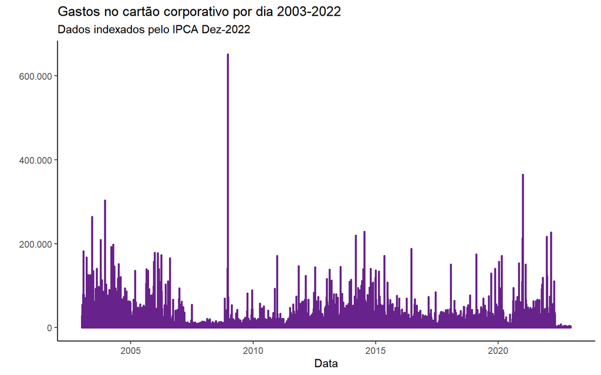

```r
p + theme_classic()
```

### Soma dos gastos no cartão corporativo por ano

```r
corporativo_year <- corporativo %>%
    group_by(year = lubridate::floor_date(DATA.PGTO, "year")) %>%
    summarize(summary_variable = sum(VALOR_DEF, na.rm  = TRUE))
```

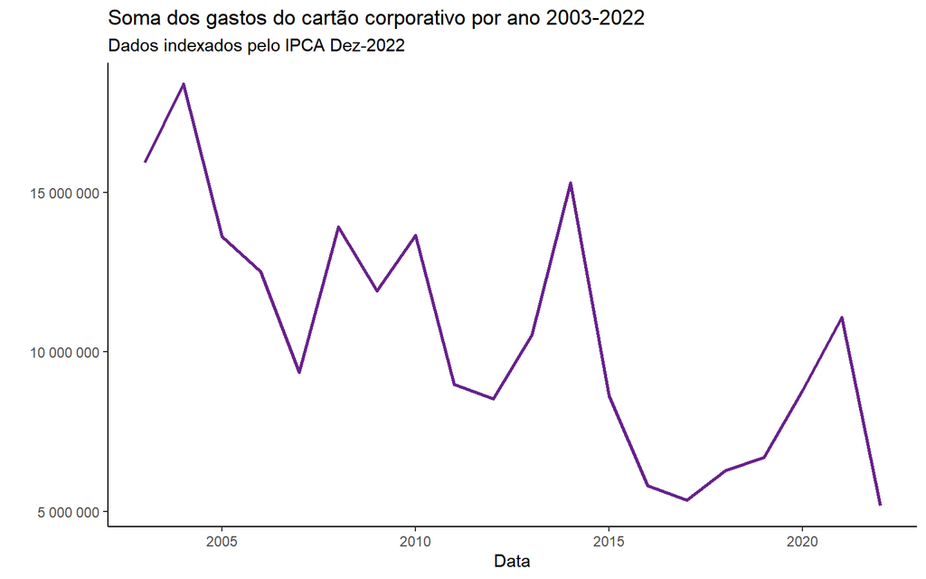

```r
ggplot(data = corporativo_year, aes(x = year, y = summary_variable)) +
  geom_line(color = "darkorchid4", size = 1) +

  labs(title = 'Soma dos gastos do cartão corporativo por ano 2003-2022',
       subtitle = 'Dados indexados pelo IPCA Dez-2022',
       y = '',
       x = 'Data') +
    scale_y_continuous(labels  = label_number(accuracy = 1))+ theme_classic()
```

```r
corporativo_year %>%
  kbl() %>%
  kable_styling(bootstrap_options = c("striped", "condensed", "responsive"), full_width = FALSE)
```

| year | summary_variable |
| --- | --- |
| 2003-01-01 | 15945340 |
| 2004-01-01 | 18390203 |
| 2005-01-01 | 13622608 |
| 2006-01-01 | 12515200 |
| 2007-01-01 | 9373558 |
| 2008-01-01 | 13914722 |
| 2009-01-01 | 11920227 |
| 2010-01-01 | 13662266 |
| 2011-01-01 | 8982480 |
| 2012-01-01 | 8542149 |
| 2013-01-01 | 10532167 |
| 2014-01-01 | 15298336 |
| 2015-01-01 | 8635526 |
| 2016-01-01 | 5815024 |
| 2017-01-01 | 5357122 |
| 2018-01-01 | 6293466 |
| 2019-01-01 | 6699446 |
| 2020-01-01 | 8793923 |
| 2021-01-01 | 11081838 |
| 2022-01-01 | 5180890 |

# 6. Gastos agrupados por subelemento de despesa

### Geral

```r
gastos_categ <- corporativo %>% group_by(SUBELEMENTO.DE.DESPESA) %>%
  summarise(
  media_def = mean(VALOR_DEF, na.rm = TRUE),
  soma_def = sum(VALOR_DEF, na.rm = TRUE)) %>%
  arrange(-soma_def) %>%
  head(5)
```

- Vamos corrigir a escrita:

```r
corporativo$SUBELEMENTO.DE.DESPESA <-  recode(corporativo$SUBELEMENTO.DE.DESPESA, 'LOCACAO DE MEIOS DE TRANSPORTE' = "LOCAÇÃO DE MEIOS DE TRANSPORTE")
corporativo$SUBELEMENTO.DE.DESPESA <- recode(corporativo$SUBELEMENTO.DE.DESPESA,"GENEROS DE ALIMENTA??" = "GENEROS DE ALIMENTAÇÃO")
corporativo$SUBELEMENTO.DE.DESPESA <- recode(corporativo$SUBELEMENTO.DE.DESPESA,"FORNECIMENTO DE ALIMENTA??" = "FORNECIMENTO DE ALIMENTAÇÃO")
corporativo$SUBELEMENTO.DE.DESPESA <- recode(corporativo$SUBELEMENTO.DE.DESPESA,"SERVI?OS DE TELECOMUNICA??S" = "SERVIÇOS DE TELECOMUNICAÇÕES")
corporativo$SUBELEMENTO.DE.DESPESA <- recode(corporativo$SUBELEMENTO.DE.DESPESA,"MATERIAL DE LIMPEZA E PROD. DE HIGIENIZA??" = "MATERIAL DE LIMPEZA E PROD. DE HIGIENIZAÇÃO")
```

```r
gastos_categ %>% kbl() %>%
  kable_styling(bootstrap_options = c("striped", "condensed", "responsive", "hover"), full_width = TRUE)
```

| SUBELEMENTO.DE.DESPESA | media_def | soma_def |
| --- | --- | --- |
| HOSPEDAGENS | 2197.978 | 99546417 |
| LOCACAO DE MEIOS DE TRANSPORTE | 15367.409 | 30888492 |
| GENEROS DE ALIMENTA?? | 1139.291 | 28390005 |
| FORNECIMENTO DE ALIMENTA?? | 3597.323 | 23735135 |
| SERV.DE APOIO ADMIN.,TECNICO E OPERACIONAL | 2637.830 | 12875250 |

- Agora podemos plotar um gráfico

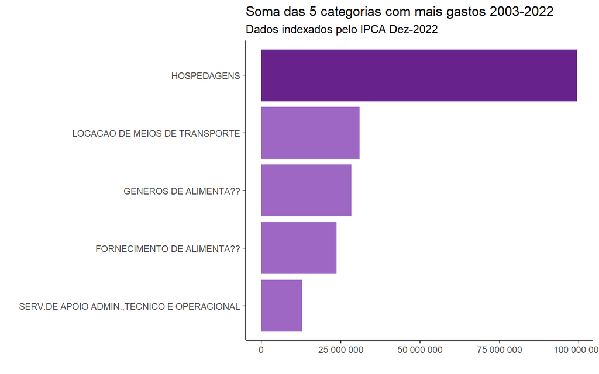

```r
gastos_categ %>%
  mutate(SUBELEMENTO.DE.DESPESA = fct_reorder(SUBELEMENTO.DE.DESPESA,soma_def ))%>%
  ggplot(aes(x = SUBELEMENTO.DE.DESPESA, y = soma_def,
             fill = factor(ifelse(SUBELEMENTO.DE.DESPESA=='HOSPEDAGENS', '...', '')))) +
  geom_bar(stat = 'identity', show.legend = FALSE) +
  scale_fill_manual(name = 'soma_def', values= c('#9E67C3', '#68228b'))+
  coord_flip() +
  labs( y = '',
       x = '') +
  ggtitle('Soma das 5 categorias com mais gastos 2003-2022',
       subtitle = 'Dados indexados pelo IPCA Dez-2022')+
  scale_y_continuous(labels  = label_number(accuracy = 1))+
  theme_classic()
```

### Gastos por categoria dividido por governo

### Lula I

#### Tabela

```r
#gastos do governo lula i
tlula_1 <-  corporativo %>% group_by(SUBELEMENTO.DE.DESPESA) %>%
  subset(DATA.PGTO >= "2003-01-02" & DATA.PGTO <= "2006-12-31",) %>%
  summarise(
  soma_def = sum(VALOR_DEF, na.rm = TRUE)) %>%
  arrange(-soma_def) %>%
  head(5)
```

| SUBELEMENTO.DE.DESPESA | soma_def |
| --- | --- |
| LOCAÇÃO DE MEIOS DE TRANSPORTE | 29326895.9 |
| HOSPEDAGENS | 18771121.1 |
| GENEROS DE ALIMENTAÇÃO | 3571066.1 |
| FORNECIMENTO DE ALIMENTAÇÃO | 3299095.6 |
| SERVIÇOS DE TELECOMUNICAÇÕES | 928133.2 |

#### Gráfico

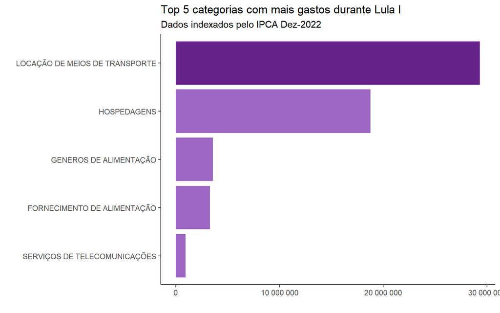

```r
tlula_1 %>% mutate(SUBELEMENTO.DE.DESPESA = fct_reorder(SUBELEMENTO.DE.DESPESA, soma_def ))%>%
  ggplot(aes(x = SUBELEMENTO.DE.DESPESA, y = soma_def,
             fill = factor(ifelse(SUBELEMENTO.DE.DESPESA=='LOCAÇÃO DE MEIOS DE TRANSPORTE', '...', '')))) +
  geom_bar(stat = 'identity', show.legend = FALSE) +
  scale_fill_manual(name = 'soma_def', values= c('#9E67C3', '#68228b')) +
  coord_flip() +
  labs(title = 'Top 5 categorias com mais gastos durante Lula I',
       subtitle = 'Dados indexados pelo IPCA Dez-2022',
       y = '',
       x = '') +
  scale_y_continuous(labels  = label_number(accuracy = 1))+
  theme_classic()
```

### Lula II

#### Tabela

```r
#gastos do governo lula ii
tlula_2 <-  corporativo %>% group_by(SUBELEMENTO.DE.DESPESA) %>%
  subset(DATA.PGTO >= "2007-01-01" & DATA.PGTO <= "2010-12-31",) %>%
  summarise(
  soma_def = sum(VALOR_DEF, na.rm = TRUE)) %>%
  arrange(-soma_def) %>%
  head(5)
```

| SUBELEMENTO.DE.DESPESA | soma_def |
| --- | --- |
| HOSPEDAGENS | 30303300 |
| GENEROS DE ALIMENTAÇÃO | 6793699 |
| FORNECIMENTO DE ALIMENTAÇÃO | 5429272 |
| SERV.DE APOIO ADMIN.,TECNICO E OPERACIONAL | 1562098 |
| LOCAÇÃO DE MEIOS DE TRANSPORTE | 1331047 |

#### Gráfico

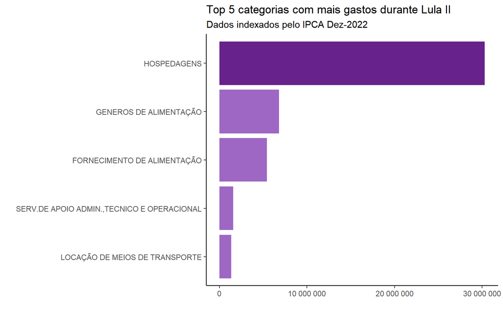

```r
tlula_2 %>% mutate(SUBELEMENTO.DE.DESPESA = fct_reorder(SUBELEMENTO.DE.DESPESA, soma_def ))%>%
  ggplot(aes(x = SUBELEMENTO.DE.DESPESA, y = soma_def,
             fill = factor(ifelse(SUBELEMENTO.DE.DESPESA=='HOSPEDAGENS', '...', '')))) +
  geom_bar(stat = 'identity', show.legend = FALSE) +
  scale_fill_manual(name = 'soma_def', values= c('#9E67C3', '#68228b')) +
  coord_flip() +
  labs(title = 'Top 5 categorias com mais gastos durante Lula II',
       subtitle = 'Dados indexados pelo IPCA Dez-2022',
       y = '',
       x = '') +
  scale_y_continuous(labels  = label_number(accuracy = 1))+
  theme_classic()
```

### Dilma

#### Tabela

```r
#gastos do governo dilma

 tdilma <- corporativo %>% group_by(SUBELEMENTO.DE.DESPESA) %>%
  subset(DATA.PGTO >= "2011-01-01" & DATA.PGTO <= "2016-08-31",) %>%
  summarise(
  soma_def = sum(VALOR_DEF, na.rm = TRUE)) %>%
  arrange(-soma_def) %>%
  head(5)
```

| SUBELEMENTO.DE.DESPESA | soma_def |
| --- | --- |
| HOSPEDAGENS | 29768534.5 |
| GENEROS DE ALIMENTAÇÃO | 9311573.5 |
| FORNECIMENTO DE ALIMENTAÇÃO | 6793463.3 |
| SERV.DE APOIO ADMIN.,TECNICO E OPERACIONAL | 5712926.1 |
| MATERIAL DE LIMPEZA E PROD. DE HIGIENIZAÇÃO | 701049.3 |

#### Gráfico

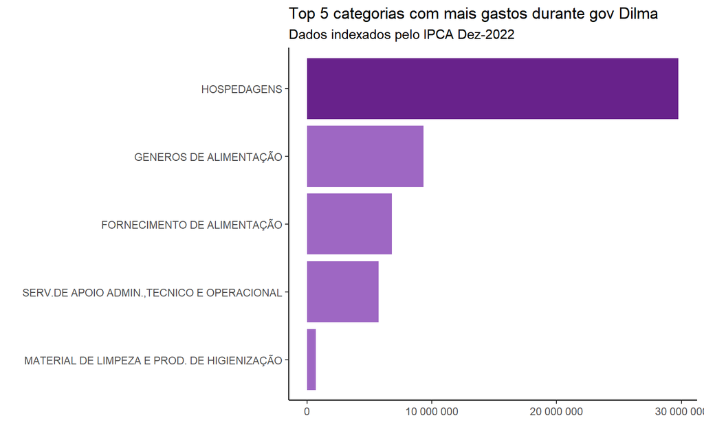

```r
tdilma %>% mutate(SUBELEMENTO.DE.DESPESA = fct_reorder(SUBELEMENTO.DE.DESPESA, soma_def ))%>%
  ggplot(aes(x = SUBELEMENTO.DE.DESPESA, y = soma_def,
             fill = factor(ifelse(SUBELEMENTO.DE.DESPESA=='HOSPEDAGENS', '...', '')))) +
  geom_bar(stat = 'identity', show.legend = FALSE) +
  scale_fill_manual(name = 'soma_def', values= c('#9E67C3', '#68228b')) +
  coord_flip() +
  labs(title = 'Top 5 categorias com mais gastos durante gov Dilma',
       subtitle = 'Dados indexados pelo IPCA Dez-2022',
       y = '',
       x = '') +
  scale_y_continuous(labels  = label_number(accuracy = 1))+
  theme_classic()
```

### Temer

#### Tabela

```r
#gastos do governo temer

 ttemer <- corporativo %>% group_by(SUBELEMENTO.DE.DESPESA) %>%
  subset(DATA.PGTO >= "2016-09-01" & DATA.PGTO <= "2018-12-31",) %>%
  summarise(
  soma_def = sum(VALOR_DEF, na.rm = TRUE)) %>%
  arrange(-soma_def) %>%
  head(5)
```

| SUBELEMENTO.DE.DESPESA | soma_def |
| --- | --- |
| HOSPEDAGENS | 4898900.85 |
| GENEROS DE ALIMENTAÇÃO | 3251868.86 |
| SERV.DE APOIO ADMIN.,TECNICO E OPERACIONAL | 2924449.04 |
| FORNECIMENTO DE ALIMENTAÇÃO | 1902444.47 |
| MATERIAL DE LIMPEZA E PROD. DE HIGIENIZAÇÃO | 89934.95 |

#### Gráfico

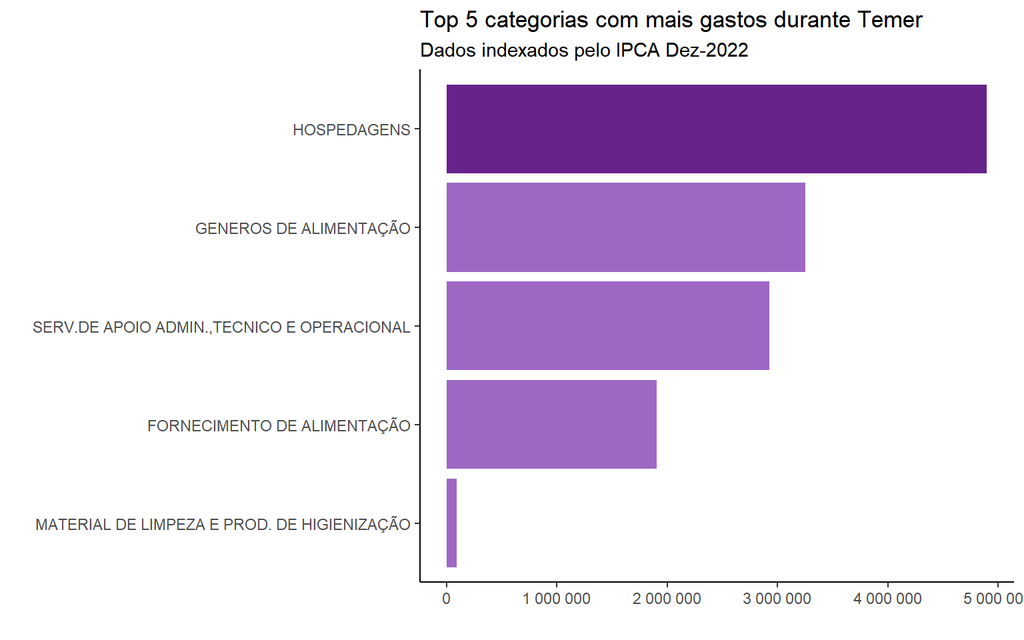

```r
ttemer %>% mutate(SUBELEMENTO.DE.DESPESA = fct_reorder(SUBELEMENTO.DE.DESPESA, soma_def ))%>%
  ggplot(aes(x = SUBELEMENTO.DE.DESPESA, y = soma_def,
             fill = factor(ifelse(SUBELEMENTO.DE.DESPESA=='HOSPEDAGENS', '...', '')))) +
  geom_bar(stat = 'identity', show.legend = FALSE) +
  scale_fill_manual(name = 'soma_def', values= c('#9E67C3', '#68228b')) +
  coord_flip() +
  labs(title = 'Top 5 categorias com mais gastos durante Temer',
       subtitle = 'Dados indexados pelo IPCA Dez-2022',
       y = '',
       x = '') +
  scale_y_continuous(labels  = label_number(accuracy = 1))+
   theme_classic()
```

### Bolsonaro

#### Tabela

```r
#gastos do governo bolsonaro

 tbolsonaro <- corporativo %>% group_by(SUBELEMENTO.DE.DESPESA) %>%
  subset(DATA.PGTO >= "2019-01-01" & DATA.PGTO <= "2021-12-31",) %>%
  summarise(
  soma_def = sum(VALOR_DEF, na.rm = TRUE)) %>%
  arrange(-soma_def) %>%
  head(5)
```

| SUBELEMENTO.DE.DESPESA | soma_def |
| --- | --- |
| HOSPEDAGENS | 13653919.4 |
| FORNECIMENTO DE ALIMENTAÇÃO | 5178499.7 |
| GENEROS DE ALIMENTAÇÃO | 4266786.5 |
| SERV.DE APOIO ADMIN.,TECNICO E OPERACIONAL | 1652050.7 |
| LOCA?? BENS MOV. OUTR. NATUREZA E INTANG?EIS | 589317.7 |

#### Gráfico

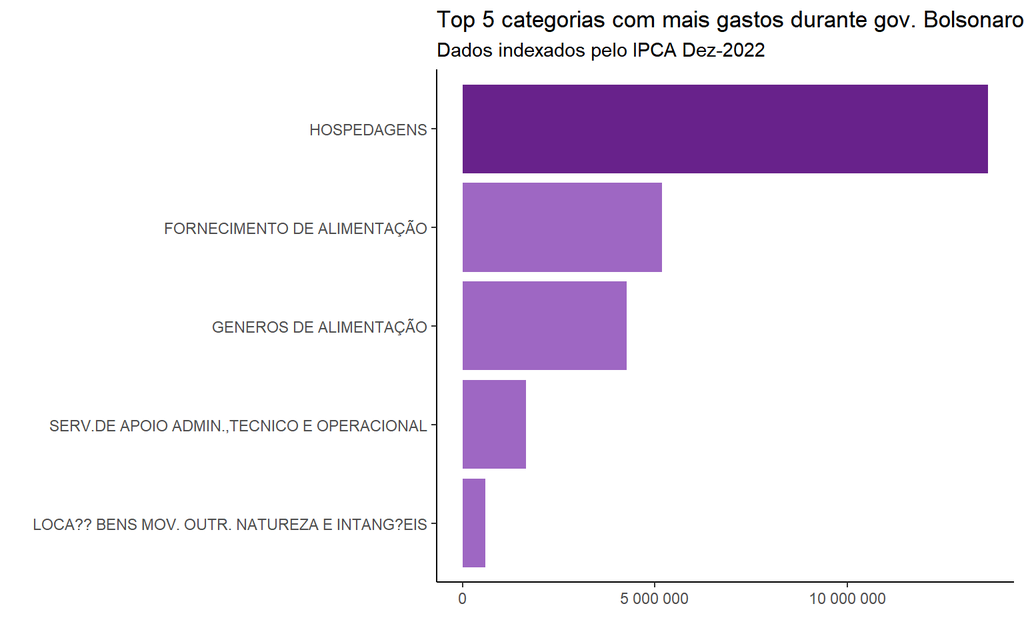

```r
tbolsonaro %>% mutate(SUBELEMENTO.DE.DESPESA = fct_reorder(SUBELEMENTO.DE.DESPESA, soma_def ))%>%
  ggplot(aes(x = SUBELEMENTO.DE.DESPESA, y = soma_def,
             fill = factor(ifelse(SUBELEMENTO.DE.DESPESA=='HOSPEDAGENS', '...', '')))) +
  geom_bar(stat = 'identity', show.legend = FALSE) +
  scale_fill_manual(name = 'soma_def', values= c('#9E67C3', '#68228b')) +
  coord_flip() +
  labs(title = 'Top 5 categorias com mais gastos durante gov. Bolsonaro',
       subtitle = 'Dados indexados pelo IPCA Dez-2022',
       y = '',
       x = '') +
  scale_y_continuous(labels  = label_number(accuracy = 1))+
   theme_classic()
```

### 2003

#### Tabela

```r
corporativo %>%
  subset(DATA.PGTO >= "2003-01-01" & DATA.PGTO <= "2003-12-31") %>%
  group_by(SUBELEMENTO.DE.DESPESA) %>%
  summarise(
  soma_def = sum(VALOR_DEF, na.rm = TRUE)) %>%
  arrange(-soma_def) %>%
  head(10)%>%
  kbl() %>%
  kable_styling(bootstrap_options = c("striped", "condensed", "responsive", "hover"), full_width = FALSE)
```

| SUBELEMENTO.DE.DESPESA | soma_def |
| --- | --- |
| LOCAÇÃO DE MEIOS DE TRANSPORTE | 9417613.97 |
| HOSPEDAGENS | 4139948.09 |
| FORNECIMENTO DE ALIMENTAÇÃO | 777691.74 |
| GENEROS DE ALIMENTAÇÃO | 447790.94 |
| COMBUSTIVEIS E LUBRIF. AUTOMOTIVOS | 202453.61 |
| OUTROS SERVI?OS DE TERCEIROS-PESSOA JUR?ICA | 160908.54 |
| MATERIAL DE LIMPEZA E PROD. DE HIGIENIZAÇÃO | 71881.81 |
| SERVIÇOS DE TELECOMUNICAÇÕES | 65240.83 |
| MANUT. E CONS. DE VE?ULOS | 56385.64 |
| SERV.DE APOIO ADMIN.,TECNICO E OPERACIONAL | 55509.17 |

#### Gráfico: Locação

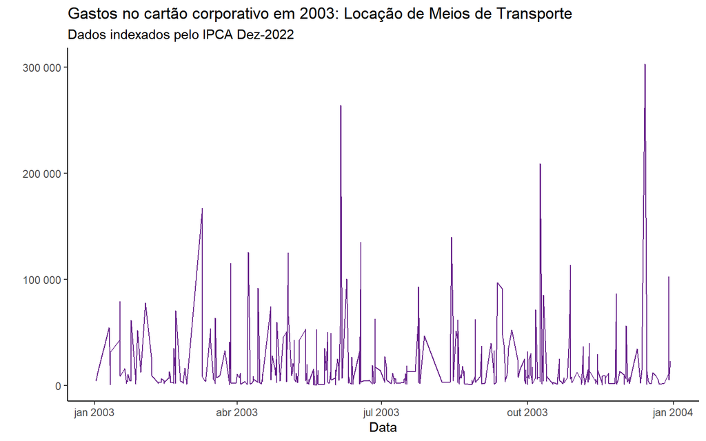

```r
corporativo %>%
  subset(DATA.PGTO >= "2003-01-01" & DATA.PGTO <= "2003-12-31") %>%
  subset(corporativo$SUBELEMENTO.DE.DESPESA == 'LOCAÇÃO DE MEIOS DE TRANSPORTE',) %>%
  ggplot(aes(x = DATA.PGTO, y = VALOR_DEF)) +
  geom_line(color = "darkorchid4", size = 0.4, na.rm=TRUE) +
  labs(title = 'Gastos no cartão corporativo em 2003: Locação de Meios de Transporte',
       subtitle = 'Dados indexados pelo IPCA Dez-2022',
       y = '',
       x = 'Data') +
    scale_y_continuous(labels  = label_number(accuracy = 1))+ theme_classic()
```

Parece que em 2003 os maiores gastos foram por volta de dezembro (talvez esteja relacionado com as festas do fim de ano

```r
corporativo %>%
  subset(corporativo$VALOR_DEF >= 600000,)%>%
  kbl() %>%
  kable_styling(bootstrap_options = c("striped", "condensed", "responsive", "hover"), full_width = FALSE)
```

|  | DATA.PGTO | NOME.FORNECEDOR | VALOR | SUBELEMENTO.DE.DESPESA | VALOR_DEF |
| --- | --- | --- | --- | --- | --- |
| 46373 | 2008-12-17 | SAUIPE S.A - SAUIPE PARK | 290176 | HOSPEDAGENS | 651219.7 |

Gasto com hotelaria, em resort.

```r
  corporativo %>%
  subset(corporativo$VALOR_DEF >= 300000,)%>%
  kbl() %>%
  kable_styling(bootstrap_options = c("striped", "condensed", "responsive", "hover"), full_width = FALSE)
```

|  | DATA.PGTO | NOME.FORNECEDOR | VALOR | SUBELEMENTO.DE.DESPESA | VALOR_DEF |
| --- | --- | --- | --- | --- | --- |
| 4662 | 2003-12-14 | FULL TIME LOCA?? E SERVI?OS S/C LTDA | 103728.4 | LOCAÇÃO DE MEIOS DE TRANSPORTE | 302776.9 |
| 46373 | 2008-12-17 | SAUIPE S.A - SAUIPE PARK | 290176.0 | HOSPEDAGENS | 651219.7 |
| 106505 | 2021-01-03 | HOTUR S PAULO PART E EMPR LTDA | 312903.4 | HOSPEDAGENS | 364307.5 |

O outro pico diário é de 2021: foram gastos 364307.5 (valores corrigidos pela inflação) em hotelaria.

### 2014

#### Tabela Geral

```r
corporativo %>%
  subset(DATA.PGTO >= "2014-01-01" & DATA.PGTO <= "2014-12-31") %>%
  group_by(SUBELEMENTO.DE.DESPESA) %>%
  summarise(
  soma_def = sum(VALOR_DEF, na.rm = TRUE)) %>%
  arrange(-soma_def) %>%
  head(10)%>%
  kbl() %>%
  kable_styling(bootstrap_options = c("striped", "condensed", "responsive", "hover"), full_width = FALSE)
```

| SUBELEMENTO.DE.DESPESA | soma_def |
| --- | --- |
| HOSPEDAGENS | 9387138.16 |
| FORNECIMENTO DE ALIMENTAÇÃO | 2318112.18 |
| GENEROS DE ALIMENTAÇÃO | 1698035.71 |
| SERV.DE APOIO ADMIN.,TECNICO E OPERACIONAL | 1122055.03 |
| MATERIAL DE LIMPEZA E PROD. DE HIGIENIZAÇÃO | 134836.84 |
| SERVIÇOS DE TELECOMUNICAÇÕES | 104422.70 |
| MATERIAL FARMACOLOGICO | 86994.29 |
| LOCA?? DE IM?EIS | 67690.72 |
| MATERIAL DE COPA E COZINHA | 51102.65 |
| LIMPEZA E CONSERVA?? | 51001.92 |

#### Gráfico: Hospedagens

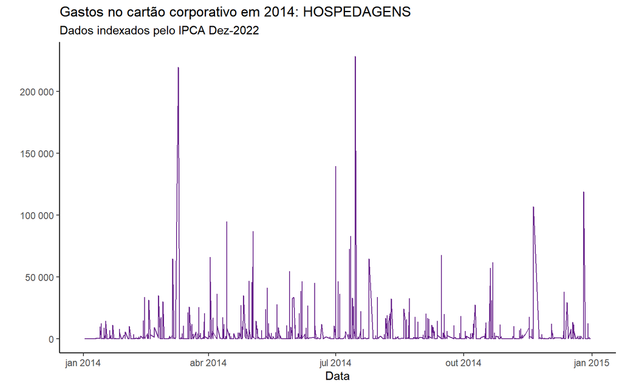

```r
corporativo %>%
  subset(DATA.PGTO >= "2014-01-01" & DATA.PGTO <= "2014-12-31") %>%
  subset(corporativo$SUBELEMENTO.DE.DESPESA == 'HOSPEDAGENS',) %>%
  ggplot(aes(x = DATA.PGTO, y = VALOR_DEF)) +
  geom_line(color = "darkorchid4", size = 0.4, na.rm=TRUE) +
  labs(title = 'Gastos no cartão corporativo em 2014: HOSPEDAGENS',
       subtitle = 'Dados indexados pelo IPCA Dez-2022',
       y = '',
       x = 'Data') +
    scale_y_continuous(labels  = label_number(accuracy = 1))+ theme_classic()
```

### 2021

#### Tabela

```r
corporativo %>%
  subset(DATA.PGTO >= "2021-01-01" & DATA.PGTO <= "2021-12-31") %>%
  group_by(SUBELEMENTO.DE.DESPESA) %>%
  summarise(
  soma_def = sum(VALOR_DEF, na.rm = TRUE)) %>%
  arrange(-soma_def) %>%
  head(10) %>%
  kbl() %>%
  kable_styling(bootstrap_options = c("striped", "condensed", "responsive", "hover"), full_width = FALSE)
```

| SUBELEMENTO.DE.DESPESA | soma_def |
| --- | --- |
| HOSPEDAGENS | 5504915.90 |
| FORNECIMENTO DE ALIMENTAÇÃO | 2278446.73 |
| GENEROS DE ALIMENTAÇÃO | 1562072.36 |
| SERV.DE APOIO ADMIN.,TECNICO E OPERACIONAL | 760960.89 |
| LOCA?? BENS MOV. OUTR. NATUREZA E INTANG?EIS | 437374.98 |
| COMBUSTIVEIS E LUBRIF. AUTOMOTIVOS | 298584.34 |
| MATERIAL DE LIMPEZA E PROD. DE HIGIENIZAÇÃO | 54658.85 |
| COMBUSTIVEIS E LUBRF. P/ OUTRAS FINALIDADES | 27989.72 |
| MATERIAL DE ACONDICIONAMENTO E EMBALAGEM | 19872.38 |
| LOCA?? DE IM?EIS | 19611.65 |

#### Gráfico: Hospedagem

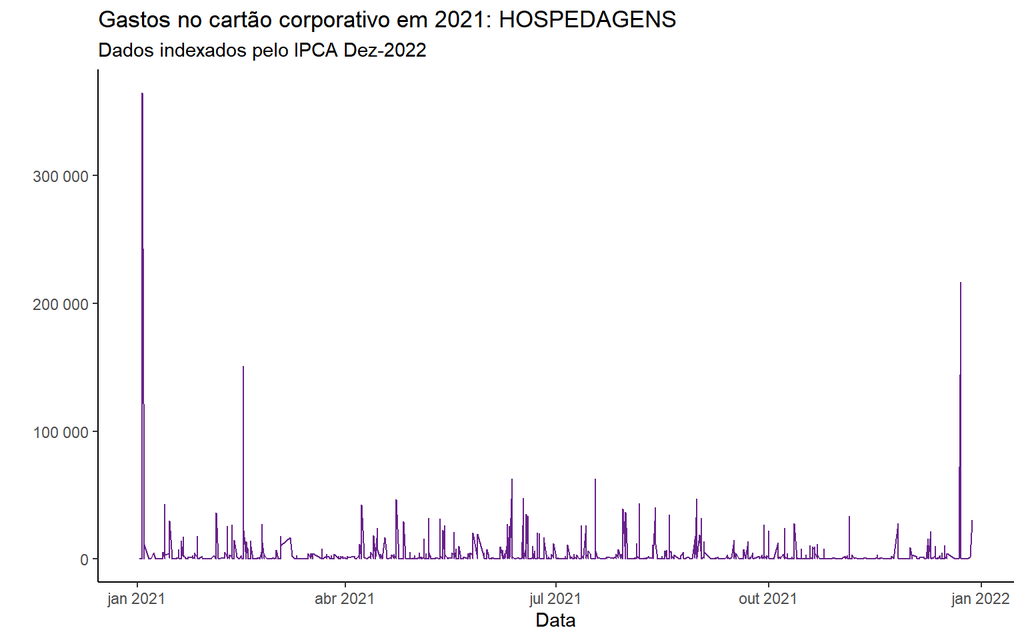

```r
corporativo %>%
  subset(DATA.PGTO >= "2021-01-01" & DATA.PGTO <= "2021-12-31") %>%
  subset(corporativo$SUBELEMENTO.DE.DESPESA == 'HOSPEDAGENS',) %>%
  ggplot(aes(x = DATA.PGTO, y = VALOR_DEF)) +
  geom_line(color = "darkorchid4", size = 0.4, na.rm=TRUE) +
  labs(title = 'Gastos no cartão corporativo em 2021: HOSPEDAGENS',
       subtitle = 'Dados indexados pelo IPCA Dez-2022',
       y = '',
       x = 'Data') +
    scale_y_continuous(labels  = label_number(accuracy = 1))+ theme_classic()
```

Novamente, hospedagem com os maiores gastos, seguido por gastos com alimentação.

# 7. Em quais estabelecimentos os presidentes mais compraram?

### Acumulativo da série:

```r
 corporativo %>%
  group_by(NOME.FORNECEDOR)%>%
  summarise(frequencia = n(), total = sum(VALOR_DEF), media = mean(VALOR_DEF),max = max(VALOR_DEF)) %>%
  arrange(-total) %>%
  head(5)  %>%
  kbl() %>%
  kable_styling(bootstrap_options = c("striped", "condensed", "responsive", "hover"), full_width = FALSE)
```

| NOME.FORNECEDOR | frequencia | total | media | max |
| --- | --- | --- | --- | --- |
| MERCADINHO LA PALMA LTDA | 3591 | 6351730 | 1768.791 | 29558.52 |
| FULL TIME LOCA?? E SERVI?OS S/C LTDA | 377 | 5721221 | 15175.651 | 302776.87 |
| COMPANHIA BRASILEIRA DE DISTRIBUI?? | 4710 | 4558705 | 967.878 | 13052.78 |
| BOURBON IBIRAPUERA HOTEL & CONVENTION | 2617 | 4407385 | 1684.137 | 110884.13 |
| P.J.P. LOCA??S E SERVI?OS LTDA - BRAS?IA RENT A | 276 | 3273551 | 11860.691 | 93727.96 |

### Lula I

#### Tab freq

```r
tab_freq_lula1 <- corporativo %>%
  subset(DATA.PGTO >= "2003-01-02" & DATA.PGTO <= "2006-12-31",) %>%
  group_by(NOME.FORNECEDOR)%>%
  summarise(frequencia = n(), total = sum(VALOR_DEF), media = mean(VALOR_DEF),max = max(VALOR_DEF)) %>%
  arrange(-frequencia) %>%
  head(5)
```

| NOME.FORNECEDOR | frequencia | total | media | max |
| --- | --- | --- | --- | --- |
| SAINT MORITZ HOT. ACCOR BRASIL S.A. | 962 | 1338617.3 | 1391.4941 | 43358.583 |
| TIMES SQUARE HOT. ACCOR BRASIL S.A | 777 | 481436.0 | 619.6088 | 10072.214 |
| CIA. INDUSTRIAL DE GRANDES HOT?IS - HOTEL GL?IA | 709 | 1235027.0 | 1741.9281 | 43874.228 |
| COMPANHIA BRASILEIRA DE DISTRIBUI?? | 626 | 538944.8 | 860.9342 | 8333.844 |
| TELEMAR NORTE LESTE S/A | 618 | 272939.3 | 441.6494 | 6291.306 |

#### Gráfico

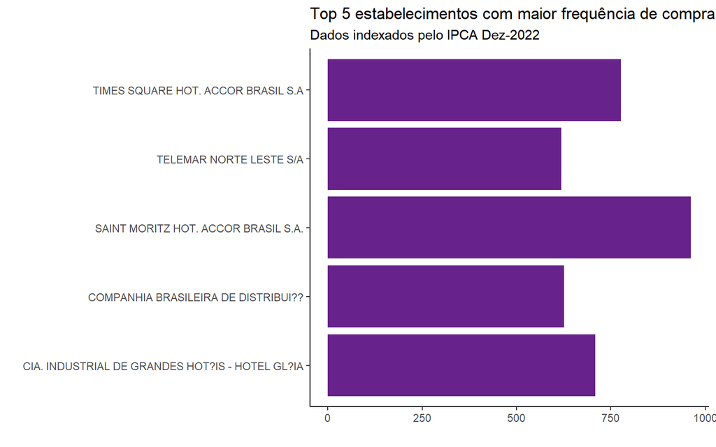

```r
tab_freq_lula1 %>%
  ggplot(aes(NOME.FORNECEDOR, frequencia)) +
  geom_bar(stat = 'identity', fill = "darkorchid4") +
  coord_flip() +
  labs(title = 'Top 5 estabelecimentos com maior frequência de compra: Lula I',
       subtitle = 'Dados indexados pelo IPCA Dez-2022',
       y = '',
       x = '') +
  theme_classic()
```

### Lula II

#### Tab freq

```r
tab_freq_lula2 <- corporativo %>%
  subset(DATA.PGTO >= "2007-01-01" & DATA.PGTO <= "2010-12-31",) %>%
  group_by(NOME.FORNECEDOR)%>%
  summarise(frequencia = n(), total = sum(VALOR_DEF), media = mean(VALOR_DEF),max = max(VALOR_DEF)) %>%
  arrange(-frequencia) %>%
  head(5)
```

| NOME.FORNECEDOR | frequencia | total | media | max |
| --- | --- | --- | --- | --- |
| ABACO SCP SAINT MORITZ | 2445 | 2046276.1 | 836.9228 | 5824.474 |
| BOURBON IBIRAPUERA HOTEL & CONVENTION | 1889 | 1853542.1 | 981.2293 | 5363.742 |
| COMPANHIA BRASILEIRA DE DISTRIBUI?? | 1094 | 1388634.7 | 1269.3187 | 13052.778 |
| TELEMAR NORTE LESTE S/A | 939 | 364637.1 | 388.3250 | 2128.455 |
| ESTANPLAZA ADMINISTRADORA HOTELARIA E COMERCIAL LT | 920 | 1873739.5 | 2036.6734 | 8572.708 |

#### Gráfico

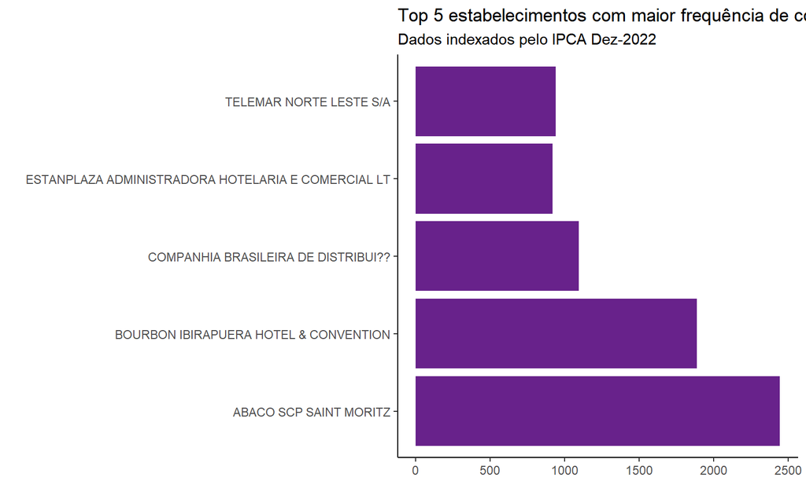

```r
tab_freq_lula2 %>%
  ggplot(aes(NOME.FORNECEDOR, frequencia)) +
  geom_bar(stat = 'identity', fill = "darkorchid4") +
  coord_flip() +
  labs(title = 'Top 5 estabelecimentos com maior frequência de compra: Lula II',
       subtitle = 'Dados indexados pelo IPCA Dez-2022',
       y = '',
       x = '') +
  theme_classic()
```

### Dilma

#### Tab freq

```r
tab_freq_dilma <- corporativo %>%
  subset(DATA.PGTO >= "2011-01-01" & DATA.PGTO <= "2016-08-31",) %>%
  group_by(NOME.FORNECEDOR)%>%
  summarise(frequencia = n(), total = sum(VALOR_DEF), media = mean(VALOR_DEF),max = max(VALOR_DEF)) %>%
  arrange(-frequencia) %>%
  head(5)
```

| NOME.FORNECEDOR | frequencia | total | media | max |
| --- | --- | --- | --- | --- |
| MERCADINHO LA PALMA LTDA | 1210 | 2268926.3 | 1875.1457 | 25300.350 |
| COMPANHIA BRASILEIRA DE DISTRIBUI?? | 904 | 836622.1 | 925.4670 | 9655.679 |
| GOLDEN TOWER HOTEIS E TURISMO LTDA | 865 | 2338946.4 | 2703.9843 | 19852.491 |
| BOURBON IBIRAPUERA HOTEL & CONVENTION | 693 | 2255611.3 | 3254.8503 | 110884.131 |
| TELEMAR NORTE LESTE S/A | 551 | 117959.7 | 214.0829 | 742.662 |

#### Gráfico

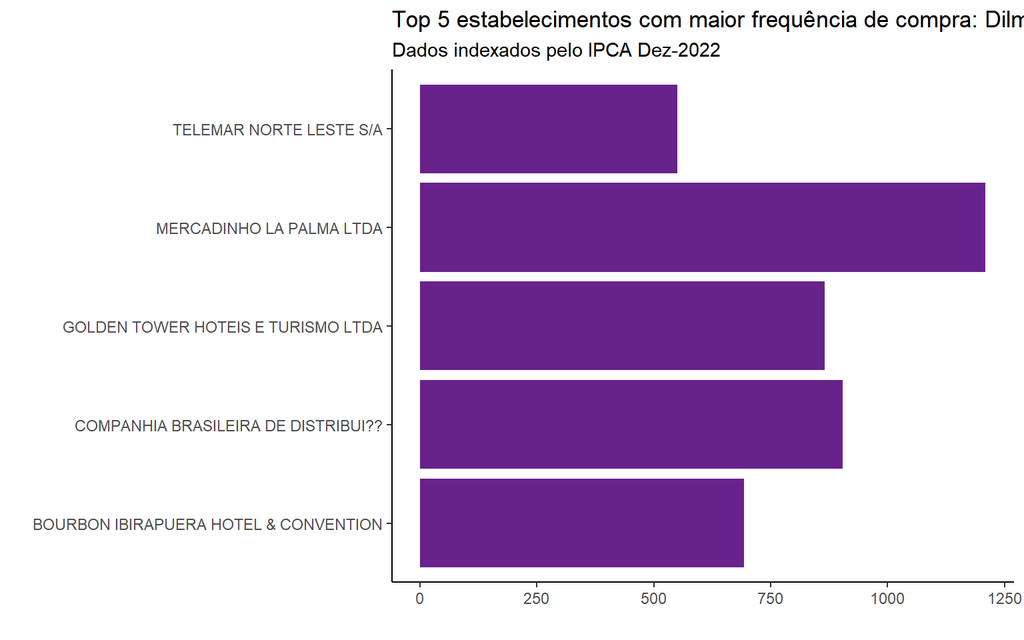

```r
tab_freq_dilma %>%
  ggplot(aes(NOME.FORNECEDOR, frequencia)) +
  geom_bar(stat = 'identity', fill = "darkorchid4") +
  coord_flip() +
  labs(title = 'Top 5 estabelecimentos com maior frequência de compra: Dilma',
       subtitle = 'Dados indexados pelo IPCA Dez-2022',
       y = '',
       x = '') +
  theme_classic()
```

### Temer

#### Tab freq

```r
tab_freq_temer <- corporativo %>%
  subset(DATA.PGTO >= "2016-09-01" & DATA.PGTO <= "2018-12-31",) %>%
  group_by(NOME.FORNECEDOR)%>%
  summarise(frequencia = n(), total = sum(VALOR_DEF), media = mean(VALOR_DEF),max = max(VALOR_DEF)) %>%
  arrange(-frequencia) %>%
  head(5)
```

| NOME.FORNECEDOR | frequencia | total | media | max |
| --- | --- | --- | --- | --- |
| MERCADINHO LA PALMA LTDA | 759 | 574704.2 | 757.1861 | 7923.946 |
| COMPANHIA BRASILEIRA DE DISTRIBUI?? | 612 | 475014.7 | 776.1678 | 11247.641 |
| BIG TRANS COMERCIAL DE ALIMENTOS LTDA | 532 | 458277.0 | 861.4229 | 4154.722 |
| SUPERMERCADO VAREJAO OBA LTDA | 415 | 271316.4 | 653.7745 | 2451.457 |
| INTERNATIONAL MEAL COMPANY ALIMENT | 265 | 506636.6 | 1911.8361 | 9625.169 |

#### Gráfico

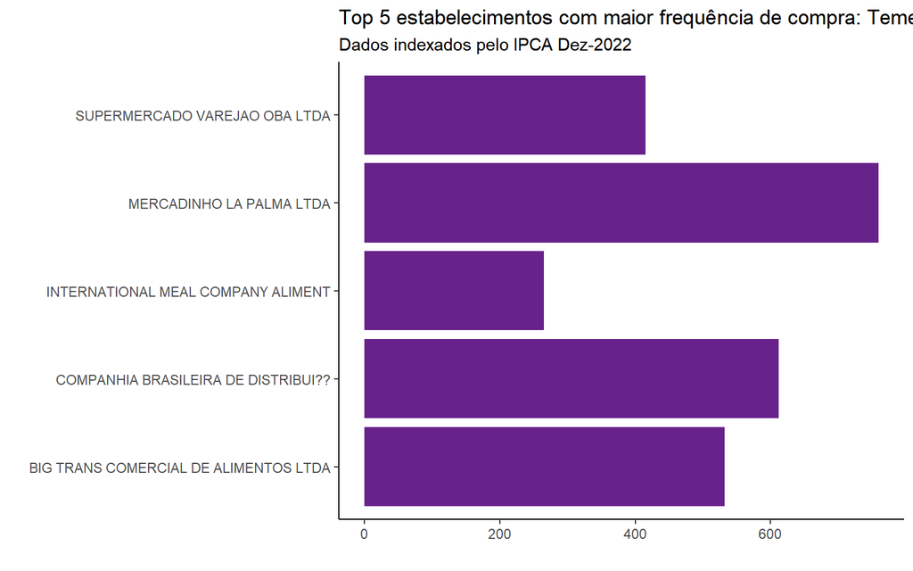

```r
tab_freq_temer%>%
  ggplot(aes(NOME.FORNECEDOR, frequencia)) +
  geom_bar(stat = 'identity', fill = "darkorchid4") +
  coord_flip() +
  labs(title = 'Top 5 estabelecimentos com maior frequência de compra: Temer',
       subtitle = 'Dados indexados pelo IPCA Dez-2022',
       y = '',
       x = '') +
  theme_classic()
```

### Bolsonaro

#### Tab freq

```r
tab_freq_bolsonaro <- corporativo %>%
  subset(DATA.PGTO >= "2019-01-01" & DATA.PGTO <= "2021-12-31",) %>%
  group_by(NOME.FORNECEDOR)%>%
  summarise(frequencia = n(), total = sum(VALOR_DEF), media = mean(VALOR_DEF),max = max(VALOR_DEF)) %>%
  arrange(-frequencia) %>%
  head(5)
```

[output not shown]

#### Gráfico

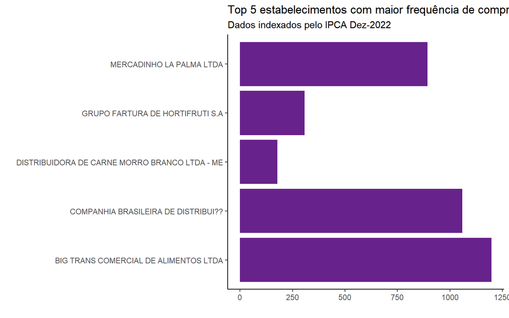

```r
tab_freq_bolsonaro%>%
  ggplot(aes(NOME.FORNECEDOR, frequencia)) +
  geom_bar(stat = 'identity', fill = "darkorchid4") +
  coord_flip() +
  labs(title = 'Top 5 estabelecimentos com maior frequência de compra: Bolsonaro',
       subtitle = 'Dados indexados pelo IPCA Dez-2022',
       y = '',
       x = '') +
  theme_classic()
```

O Mercadinho La Palma parece ser um favorito entre os presidentes.

Tanto é um favorito que nos últimos 20 anos foi quem mais faturou com gastos no cartão corporativo de 6.351.730 reais:

```r
corporativo %>%
  group_by(NOME.FORNECEDOR)%>%
  summarise(frequencia = n(), total = sum(VALOR_DEF), media = mean(VALOR_DEF),max = max(VALOR_DEF)) %>%
  arrange(-total) %>%
  head(5) %>%
  kbl() %>%
  kable_styling(bootstrap_options = c("striped", "condensed", "responsive", "hover"), full_width = FALSE)
```

| NOME.FORNECEDOR | frequencia | total | media | max |
| --- | --- | --- | --- | --- |
| MERCADINHO LA PALMA LTDA | 3591 | 6351730 | 1768.791 | 29558.52 |
| FULL TIME LOCA?? E SERVI?OS S/C LTDA | 377 | 5721221 | 15175.651 | 302776.87 |
| COMPANHIA BRASILEIRA DE DISTRIBUI?? | 4710 | 4558705 | 967.878 | 13052.78 |
| BOURBON IBIRAPUERA HOTEL & CONVENTION | 2617 | 4407385 | 1684.137 | 110884.13 |
| P.J.P. LOCA??S E SERVI?OS LTDA - BRAS?IA RENT A | 276 | 3273551 | 11860.691 | 93727.96 |

## O Mercadinho La Palma LTDA ao longo dos anos…

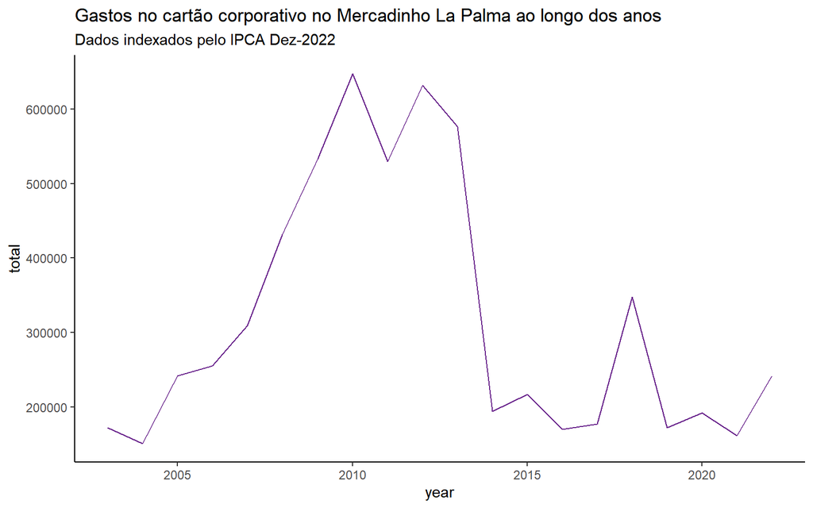

```r
 corporativo %>%
  subset(corporativo$NOME.FORNECEDOR == 'MERCADINHO LA PALMA LTDA',) %>%
  group_by(year = lubridate::floor_date(DATA.PGTO, "year")) %>%
  summarize(total = sum(VALOR_DEF, na.rm  = TRUE)) %>%
  ggplot(aes(x = year, y = total)) +
  geom_line(color = "darkorchid4", size = 0.4, na.rm=TRUE) +
  labs(title = 'Gastos no cartão corporativo no Mercadinho La Palma ao longo dos anos',
       subtitle = 'Dados indexados pelo IPCA Dez-2022')  + theme_classic()
```

[^1]: [A planilha de gastos pode ser encontrada aqui](https://www.gov.br/secretariageral/pt-br/acesso-a-informacao/informacoes-classificadas-e-desclassificadas)
[^2]: [Mais sobre o pacote](https://fmeireles.com/blog/rstats/deflacionar-series-no-r-deflatebr/)
[^3]: [Gasto de Bolsonaro com cartão corporativo foi quase o triplo do divulgado](https://noticias.uol.com.br/politica/ultimas-noticias/2023/01/17/gastos-cartao-corporativo-maiores-divulgado.htm)
[^4]: [Gastos de Bolsonaro com cartão corporativo podem ter sido maiores do que o divulgado, diz jornalista](https://g1.globo.com/podcast/o-assunto/noticia/2023/01/17/gastos-de-bolsonaro-com-cartao-corporativo-podem-ter-sido-maiores-do-que-o-divulgado-diz-jornalista.ghtml)